# 09 - Mixed Effects Models Answers

# Introduction and Setup

```r
library(tidyverse)
library(lme4)
```

```r
dat <- read_csv("inputs/factorial_data.csv")
```

## Question 1

Summarise the data, creating means, standard deviations, and ns for each group in the data set.

```r
dat %>%
  group_by(A, B) %>%
  summarise(mean = mean(Y),
            sd = sd(Y),
            n = n()
            )
```

| A | B | mean | sd | n |
| --- | --- | --- | --- | --- |
| A1 | B1 | 247.2908 | 28.40969 | 600 |
| A1 | B2 | 245.2599 | 21.22955 | 600 |
| A2 | B1 | 248.5687 | 36.35346 | 600 |
| A2 | B2 | 260.3416 | 29.83057 | 600 |

## Question 2

Centre the factors A and B in preparation for fitting the model. Define the centred variables for A and B as **A_c** and **B_c** respectively. Return the data set to see what you did to the data frame.

```r
dat$A_c <- (dat$A == "A1") - mean(dat$A == "A1")
dat$B_c <- (dat$B == "B1") - mean(dat$B == "B1")
dat
```

| X1 | subj_id | list_id | item_id | A | B | Y | A_c | B_c |
| --- | --- | --- | --- | --- | --- | --- | --- | --- |
| 1 | 1 | 4 | 1 | A2 | B2 | 244.3068 | -0.5 | -0.5 |
| 2 | 1 | 4 | 2 | A2 | B2 | 266.4218 | -0.5 | -0.5 |
| 3 | 1 | 4 | 3 | A2 | B2 | 301.0725 | -0.5 | -0.5 |
| 4 | 1 | 4 | 4 | A2 | B2 | 263.5179 | -0.5 | -0.5 |
| 5 | 1 | 4 | 5 | A2 | B2 | 255.7244 | -0.5 | -0.5 |
| 6 | 1 | 4 | 6 | A2 | B2 | 251.6233 | -0.5 | -0.5 |
| 7 | 1 | 4 | 7 | A2 | B2 | 247.3770 | -0.5 | -0.5 |
| 8 | 1 | 4 | 8 | A2 | B2 | 305.7595 | -0.5 | -0.5 |
| 9 | 1 | 4 | 9 | A2 | B2 | 252.1208 | -0.5 | -0.5 |
| 10 | 1 | 4 | 10 | A2 | B2 | 264.5693 | -0.5 | -0.5 |

[output cut: 990 more lines]

## Question 3

1. Find maximal random effects structure for the model and call this **maximal_model**. Return the a summary of the model output when you’re done. Assume that the data from which this is taken is not nested. This model may take a while to fit, so be patient!
2. Where is most of the variance explained? What does this tell us about the model (i.e. is it overfitting the data)?
3. Are there any perfect correlations between the random effects? What does this tell us about our random effects structure?

```r
maximal_model <- lmer(Y ~ A_c * B_c +
                        (1 + A_c * B_c | subj_id) +
                        (1 + A_c * B_c | item_id),
                      data = dat
                      )
summary(maximal_model)
```

```
Linear mixed model fit by REML ['lmerMod']
Formula: Y ~ A_c * B_c + (1 + A_c * B_c | subj_id) + (1 + A_c * B_c |      item_id)
   Data: dat

REML criterion at convergence: 21299.6

Scaled residuals:
     Min       1Q   Median       3Q      Max
-2.98784 -0.64014  0.02281  0.63511  3.02488

Random effects:
 Groups   Name        Variance Std.Dev. Corr
 subj_id  (Intercept) 165.9    12.88
          A_c         183.0    13.53    -0.82
          B_c         217.7    14.76     0.80 -0.61
          A_c:B_c     272.2    16.50     0.52 -0.75  0.39
 item_id  (Intercept) 152.7    12.36
          A_c         266.3    16.32    -0.39
          B_c         212.8    14.59     0.46 -0.03
          A_c:B_c     194.0    13.93     0.17 -0.16 -0.57
 Residual             313.1    17.70
Number of obs: 2400, groups:  subj_id, 60; item_id, 40

Fixed effects:
            Estimate Std. Error t value
(Intercept)  250.365      2.591   96.64
A_c           -8.180      3.198   -2.56
B_c           -4.871      3.078   -1.58
A_c:B_c       13.804      3.388    4.07

Correlation of Fixed Effects:
        (Intr) A_c    B_c
A_c     -0.522
B_c      0.576 -0.228
A_c:B_c  0.293 -0.343 -0.124
```

**b. Answer**: Most of the variance is explained by the residuals. This means that we are unlikely to be overfitting the model, as our model doesn’t explain all of the variance by our fixed and random factors.

**c. Answer**: None of the random effects are perfectly correlated. This means that there the random effects cannot be perfectly collinear.

## Question 4

Explore the whether inclusion of the interaction significantly improves model fit over a model with just main effects. Be sure to include all random effects in all models.

```r
interaction_mod <- lmer(Y ~ A_c * B_c +
                          (1 + A_c * B_c | subj_id) +
                          (1 + A_c * B_c | item_id),
                        data = dat,
                        REML = F
                        )
main_mod <- lmer(Y ~ A_c + B_c +
                   (1 + A_c * B_c | subj_id) +
                   (1 + A_c * B_c | item_id),
                 data = dat,
                 REML = F
                 )
anova(interaction_mod, main_mod)
```

```
Data: dat
Models:
main_mod: Y ~ A_c + B_c + (1 + A_c * B_c | subj_id) + (1 + A_c * B_c |
main_mod:     item_id)
interaction_mod: Y ~ A_c * B_c + (1 + A_c * B_c | subj_id) + (1 + A_c * B_c |
interaction_mod:     item_id)
                Df   AIC   BIC logLik deviance  Chisq Chi Df Pr(>Chisq)
main_mod        24 21378 21517 -10665    21330
interaction_mod 25 21365 21509 -10657    21315 14.974      1   0.000109 ***
---
Signif. codes:  0 *** 0.001 ** 0.01 * 0.05 . 0.1   1
```

## Question 5

```r
interaction_mod %>%
  broom::tidy("fixed") %>%
  mutate(p_value = 2*(1 - pnorm(abs(statistic)))) %>%
  mutate_if(is.numeric, funs(round(., 4)))
```

| term | estimate | std.error | statistic | p_value |
| --- | --- | --- | --- | --- |
| (Intercept) | 250.3653 | 2.5737 | 97.2802 | 0.0000 |
| A_c | -8.1798 | 3.1711 | -2.5795 | 0.0099 |
| B_c | -4.8710 | 3.0543 | -1.5948 | 0.1108 |
| A_c:B_c | 13.8038 | 3.3561 | 4.1131 | 0.0000 |

## Question 6

Explore the interaction by subsetting the data to each level of factor A and fitting a model containing factor B. Then do the same for the remaining factor. Where does the interaction lie?

First, subset the data as described above, and assign this to four objects called A1_dat, A2_dat, B1_dat, and B2_dat respectively.

```r
A1_dat <- dat %>% filter(A == "A1")
A2_dat <- dat %>% filter(A == "A2")
B1_dat <- dat %>% filter(B == "B1")
B2_dat <- dat %>% filter(B == "B2")
```

Then, fit four models looking at the main effect of one factor within each subset of data.

```r
A1_mod <- lmer(Y ~ B_c + (1 + B_c | subj_id) + (1 + B_c | item_id), dat = A1_dat)
A2_mod <- lmer(Y ~ B_c + (1 + B_c | subj_id) + (1 + B_c | item_id), dat = A2_dat)
B1_mod <- lmer(Y ~ A_c + (1 + A_c | subj_id) + (1 + A_c | item_id), dat = B1_dat)
B2_mod <- lmer(Y ~ A_c + (1 + A_c | subj_id) + (1 + A_c | item_id), dat = B2_dat)
```

Next, extract a tidied version of the coefficients from each model and add a column identifying which comparison these models are from. Assign these to A1_comp, A2_comp, B1_comp and B2_comp respectively, showing that these objects contain the comparisons for each level.

```r
# extract tidied model outputs
A1_comp <- A1_mod %>% broom::tidy("fixed") %>% mutate(comparison = "A1_vs_B")
A2_comp <- A2_mod %>% broom::tidy("fixed") %>% mutate(comparison = "A2_vs_B")
B1_comp <- B1_mod %>% broom::tidy("fixed") %>% mutate(comparison = "B1_vs_A")
B2_comp <- B2_mod %>% broom::tidy("fixed") %>% mutate(comparison = "B2_vs_A")
```

Finally, bind the rows together from your comparisons, and create a *p*-value for your data using the normal approximation. Be sure to bonferroni correct your data. After the correction, make sure that you reset any *p*-values above 1 to 1 (as *p*-values above 1 don’t make any sense).

```r
# set bonferroni correction
bonferroni_correction <- 4
# bind together
all_estimates <- bind_rows(A1_comp, A2_comp, B1_comp, B2_comp) %>%
  mutate(p_value = 2*(1 - pnorm(abs(statistic)))*bonferroni_correction,
         p_value = ifelse(p_value > 1, 1, p_value)
         )
# show result
all_estimates %>% select(comparison, everything())
```

| comparison | term | estimate | std.error | statistic | p_value |
| --- | --- | --- | --- | --- | --- |
| A1_vs_B | (Intercept) | 246.275364 | 2.241626 | 109.8645975 | 0.0000000000 |
| A1_vs_B | B_c | 2.030937 | 3.328870 | 0.6100981 | 1.0000000000 |
| A2_vs_B | (Intercept) | 254.455178 | 3.689891 | 68.9600778 | 0.0000000000 |
| A2_vs_B | B_c | -11.772893 | 3.689578 | -3.1908503 | 0.0056741904 |
| B1_vs_A | (Intercept) | 247.929782 | 3.693561 | 67.1248614 | 0.0000000000 |
| B1_vs_A | A_c | -1.277899 | 3.059595 | -0.4176694 | 1.0000000000 |
| B2_vs_A | (Intercept) | 252.800759 | 2.102009 | 120.2662520 | 0.0000000000 |
| B2_vs_A | A_c | -15.081729 | 4.058408 | -3.7161685 | 0.0008090668 |

**Answer**: There is a significant effect of B on A2, there is also a significant effect of A on B2.

## Question 7

Make a plot showing the interaction between A and B.

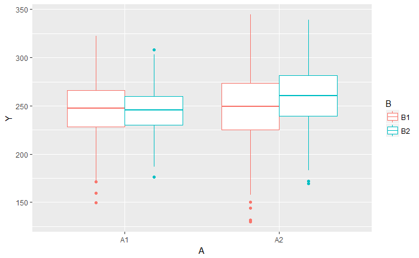

```r
ggplot(data = dat, mapping = aes(x = A, y = Y, colour = B)) + geom_boxplot()
```